# Lab 12

Author

Olivia Kelly

```r
library(neonUtilities)
library(tidyverse)
library(lubridate)
library(DT)
library(viridis)
```

```r
library(tidyverse)
library(lubridate)
library(DT)
library(viridis)
```

```r
soilChem <- loadByProduct(
  dpID='DP1.10086.001',
  startdate = "2023-01",
  enddate = "2023-12",
  check.size = FALSE,
  package='expanded')
```

```r
soilChem$sls_metagenomicsPooling[5,'genomicsSampleID']
```

```
[1] "HARV_013-O-20230704-COMP"
```

```r
soilChem$sls_metagenomicsPooling[5,'collectDate']
```

```
[1] "2023-07-04 19:03:00 UTC"
```

```r
soilChem$sls_metagenomicsPooling$genomicsPooledIDList[5]
```

```
[1] "HARV_013-O-39-20230704|HARV_013-O-41-20230704|HARV_013-O-23-20230704"
```

```r
# View(soilChem$sls_soilChemistry # No soil chemistry data for HARV
soilChem$sls_soilMoisture |>
  filter(sampleID == "HARV_013-O-39-20230704") |>
  select(sampleID, soilMoisture)
```

```
                sampleID soilMoisture
1 HARV_013-O-39-20230704        3.223
```

```r
# split up the pooled list into new columns
genomicSamples <- soilChem$sls_metagenomicsPooling |>
  tidyr::separate(genomicsPooledIDList, into=c("first","second","third"),sep="\\|",fill="right") |>
  dplyr::select(genomicsSampleID,first,second,third)

head(genomicSamples)
```

```
          genomicsSampleID                  first                 second
1 HARV_034-O-20230703-COMP HARV_034-O-23-20230703 HARV_034-O-41-20230703
2 HARV_033-O-20230703-COMP HARV_033-O-39-20230703 HARV_033-O-21-20230703
3 HARV_035-O-20230704-COMP HARV_035-O-23-20230704 HARV_035-O-41-20230704
4 HARV_037-O-20230704-COMP HARV_037-O-41-20230704 HARV_037-O-21-20230704
5 HARV_013-O-20230704-COMP HARV_013-O-39-20230704 HARV_013-O-41-20230704
6 HARV_001-O-20230705-COMP HARV_001-O-41-20230705 HARV_001-O-21-20230705
                   third
1 HARV_034-O-39-20230703
2 HARV_033-O-41-20230703
3 HARV_035-O-21-20230704
4 HARV_037-O-23-20230704
5 HARV_013-O-23-20230704
6 HARV_001-O-23-20230705
```

```r
genSampleExample <- genomicSamples |>
  tidyr::pivot_longer(cols=c("first","second","third"),values_to = "sampleID") |>
  dplyr::select(sampleID,genomicsSampleID) |>
  drop_na()
```

```r
chemEx <- soilChem$sls_soilMoisture |>
  dplyr::select(sampleID,soilMoisture)

## now combine the tables
combinedTab <- left_join(genSampleExample,chemEx, by = "sampleID") |> drop_na()

## Show the data table
head(combinedTab)
```

```
# A tibble: 6 × 3
  sampleID               genomicsSampleID         soilMoisture
  <chr>                  <chr>                           <dbl>
1 HARV_034-O-23-20230703 HARV_034-O-20230703-COMP         3.41
2 HARV_034-O-41-20230703 HARV_034-O-20230703-COMP         2.98
3 HARV_034-O-39-20230703 HARV_034-O-20230703-COMP         2.70
4 HARV_033-O-39-20230703 HARV_033-O-20230703-COMP         3.48
5 HARV_033-O-21-20230703 HARV_033-O-20230703-COMP         2.76
6 HARV_033-O-41-20230703 HARV_033-O-20230703-COMP         3.31
```

```r
soilpH_Example <- soilChem$sls_soilpH %>%
  dplyr::filter(sampleID %in% combinedTab$sampleID) %>%
  dplyr::select(sampleID,soilInWaterpH,soilInCaClpH)

# now join with the existing table
combinedTab_pH <- left_join(combinedTab,soilpH_Example, by = "sampleID")

# and the final
head(combinedTab_pH)
```

```
# A tibble: 6 × 5
  sampleID              genomicsSampleID soilMoisture soilInWaterpH soilInCaClpH
  <chr>                 <chr>                   <dbl>         <dbl>        <dbl>
1 HARV_034-O-23-202307… HARV_034-O-2023…         3.41          3.45         2.7
2 HARV_034-O-41-202307… HARV_034-O-2023…         2.98          3.28         2.6
3 HARV_034-O-39-202307… HARV_034-O-2023…         2.70          3.34         2.71
4 HARV_033-O-39-202307… HARV_033-O-2023…         3.48          3.85         3.04
5 HARV_033-O-21-202307… HARV_033-O-2023…         2.76          3.99         3.29
6 HARV_033-O-41-202307… HARV_033-O-2023…         3.31          3.63         2.84
```

```r
# Remember to install the respirometry package
library(respirometry)

genome_groups_pH <- combinedTab_pH %>%
  group_by(genomicsSampleID) %>%
  summarize_at(c("soilInWaterpH","soilInCaClpH"), mean_pH)

head(genome_groups_pH)
```

```
# A tibble: 6 × 3
  genomicsSampleID         soilInWaterpH soilInCaClpH
  <chr>                            <dbl>        <dbl>
1 BONA_001-O-20230710-COMP          3.99         3.45
2 BONA_002-O-20230711-COMP          4.35         3.82
3 BONA_004-O-20230712-COMP          3.69         3.10
4 BONA_006-O-20230710-COMP          4.05         3.48
5 BONA_009-O-20230711-COMP          4.08         3.50
6 BONA_013-O-20230710-COMP          3.97         3.42
```

```r
genome_groups_all_mean <- combinedTab_pH %>%
  group_by(genomicsSampleID) %>%
  {left_join(
    summarize_at(.,vars("soilMoisture"), mean),
    summarize_at(.,vars("soilInWaterpH","soilInCaClpH"), mean_pH)
  )}

head(genome_groups_all_mean)
```

```
# A tibble: 6 × 4
  genomicsSampleID         soilMoisture soilInWaterpH soilInCaClpH
  <chr>                           <dbl>         <dbl>        <dbl>
1 BONA_001-O-20230710-COMP         1.55          3.99         3.45
2 BONA_002-O-20230711-COMP         1.14          4.35         3.82
3 BONA_004-O-20230712-COMP         3.55          3.69         3.10
4 BONA_006-O-20230710-COMP         2.54          4.05         3.48
5 BONA_009-O-20230711-COMP         1.93          4.08         3.50
6 BONA_013-O-20230710-COMP         2.45          3.97         3.42
```

## **Exercises**

### **Exercise** 1.

The dataframe sls_soilCoreCollection contains alot of useful information for analyzing the NEON MAGs. Create a new dataframe `coreCollectionSubset` with just the following columns

- sampleID
- decimalLatitude
- decimalLongitude
- elevation
- soilTemp

```r
coreCollectionSubset <- soilChem$sls_soilCoreCollection[, c("sampleID","decimalLatitude", "decimalLongitude", "elevation", "soilTemp")]

 head(coreCollectionSubset)
```

```
                sampleID decimalLatitude decimalLongitude elevation soilTemp
1 BART_040-O-39-20230605        44.06576        -71.29199     260.2     10.5
2 BART_040-O-21-20230605        44.06576        -71.29199     260.2     10.1
3 BART_040-O-23-20230605        44.06576        -71.29199     260.2     10.0
4 BART_071-O-39-20230605        44.06794        -71.29062     256.4     10.1
5 BART_071-O-21-20230605        44.06794        -71.29062     256.4     10.0
6 BART_071-O-23-20230605        44.06794        -71.29062     256.4     10.1
```

### **Exercise 2**

Following the above examples with `chemEx` join `genSampleExample` and `coreCollectionSubset`.

```r
library(dplyr)

combinedTab <- left_join(genSampleExample, chemEx, by = "sampleID") %>%
  drop_na()

combinedTab_full <- left_join(combinedTab, coreCollectionSubset, by = "sampleID")

head(combinedTab_full)
```

```
# A tibble: 6 × 7
  sampleID        genomicsSampleID soilMoisture decimalLatitude decimalLongitude
  <chr>           <chr>                   <dbl>           <dbl>            <dbl>
1 HARV_034-O-23-… HARV_034-O-2023…         3.41            42.5            -72.2
2 HARV_034-O-41-… HARV_034-O-2023…         2.98            42.5            -72.2
3 HARV_034-O-39-… HARV_034-O-2023…         2.70            42.5            -72.2
4 HARV_033-O-39-… HARV_033-O-2023…         3.48            42.5            -72.2
5 HARV_033-O-21-… HARV_033-O-2023…         2.76            42.5            -72.2
6 HARV_033-O-41-… HARV_033-O-2023…         3.31            42.5            -72.2
# ℹ 2 more variables: elevation <dbl>, soilTemp <dbl>
```

### **Exercise 3**

Get the mean for each mean for each metagenome `genomicsSampleID` for each column in your data frame from Ex. 2.

```r
genome_groups_all_mean <- combinedTab_full %>%
  group_by(genomicsSampleID) %>%
  summarize(
    soilMoisture     = mean(soilMoisture, na.rm = TRUE),
    decimalLatitude  = mean(decimalLatitude, na.rm = TRUE),
    decimalLongitude = mean(decimalLongitude, na.rm = TRUE),
    elevation        = mean(elevation, na.rm = TRUE),
    soilTemp         = mean(soilTemp, na.rm = TRUE)
  )

head(genome_groups_all_mean)
```

```
# A tibble: 6 × 6
  genomicsSampleID       soilMoisture decimalLatitude decimalLongitude elevation
  <chr>                         <dbl>           <dbl>            <dbl>     <dbl>
1 BONA_001-O-20230710-C…         1.55            65.2            -147.      374.
2 BONA_002-O-20230711-C…         1.14            65.2            -148.      484.
3 BONA_004-O-20230712-C…         3.55            65.2            -148.      669.
4 BONA_006-O-20230710-C…         2.54            65.2            -148.      507
5 BONA_009-O-20230711-C…         1.93            65.2            -148.      430.
6 BONA_013-O-20230710-C…         2.45            65.2            -148.      540.
# ℹ 1 more variable: soilTemp <dbl>
```

### **Exercise 4**

Join the data frame from Ex. 3 with the soil moisture and pH measurements in `genome_groups_all_mean`.

```r
combinedTab_all <- left_join(combinedTab_full, soilpH_Example, by = "sampleID")

genome_groups_all_mean <- combinedTab_all %>%
  group_by(genomicsSampleID) %>%
  summarize(
    soilMoisture     = mean(soilMoisture, na.rm = TRUE),
    soilInWaterpH    = mean_pH(soilInWaterpH),
    soilInCaClpH     = mean_pH(soilInCaClpH),
    decimalLatitude  = mean(decimalLatitude, na.rm = TRUE),
    decimalLongitude = mean(decimalLongitude, na.rm = TRUE),
    elevation        = mean(elevation, na.rm = TRUE),
    soilTemp         = mean(soilTemp, na.rm = TRUE)
  )

head(genome_groups_all_mean)
```

```
# A tibble: 6 × 8
  genomicsSampleID       soilMoisture soilInWaterpH soilInCaClpH decimalLatitude
  <chr>                         <dbl>         <dbl>        <dbl>           <dbl>
1 BONA_001-O-20230710-C…         1.55          3.99         3.45            65.2
2 BONA_002-O-20230711-C…         1.14          4.35         3.82            65.2
3 BONA_004-O-20230712-C…         3.55          3.69         3.10            65.2
4 BONA_006-O-20230710-C…         2.54          4.05         3.48            65.2
5 BONA_009-O-20230711-C…         1.93          4.08         3.50            65.2
6 BONA_013-O-20230710-C…         2.45          3.97         3.42            65.2
# ℹ 3 more variables: decimalLongitude <dbl>, elevation <dbl>, soilTemp <dbl>
```

### **Exercise 5**

Using the `genomicsSampleID` column, make a new column with the siteID (e.g. HARV). There is a similar example in lab 6 where we parsed the NEON MAG data.

```r
genome_groups_all_mean <- genome_groups_all_mean %>%
  mutate(siteID = sub("_.*", "", genomicsSampleID))

head(genome_groups_all_mean)
```

```
# A tibble: 6 × 9
  genomicsSampleID       soilMoisture soilInWaterpH soilInCaClpH decimalLatitude
  <chr>                         <dbl>         <dbl>        <dbl>           <dbl>
1 BONA_001-O-20230710-C…         1.55          3.99         3.45            65.2
2 BONA_002-O-20230711-C…         1.14          4.35         3.82            65.2
3 BONA_004-O-20230712-C…         3.55          3.69         3.10            65.2
4 BONA_006-O-20230710-C…         2.54          4.05         3.48            65.2
5 BONA_009-O-20230711-C…         1.93          4.08         3.50            65.2
6 BONA_013-O-20230710-C…         2.45          3.97         3.42            65.2
# ℹ 4 more variables: decimalLongitude <dbl>, elevation <dbl>, soilTemp <dbl>,
#   siteID <chr>
```

### **Exercise 6**

Make a box plot with the soilpH by siteID

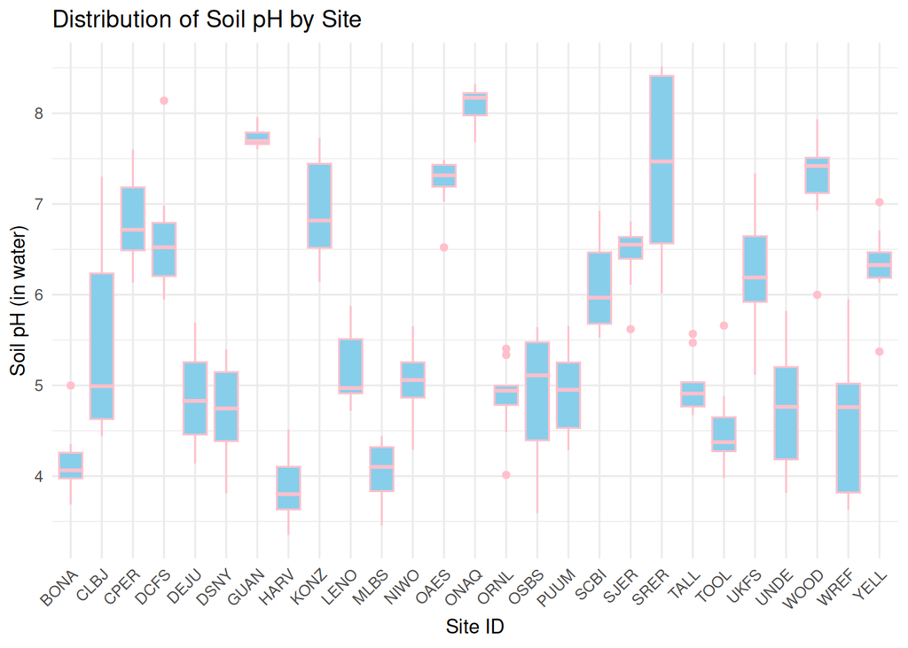

```r
ggplot(genome_groups_all_mean, aes(x = siteID, y = soilInWaterpH)) +
  geom_boxplot(fill = "skyblue", color = "pink") +
  labs(
    title = "Distribution of Soil pH by Site",
    x = "Site ID",
    y = "Soil pH (in water)"
  ) +
  theme_minimal()+
  theme(axis.text.x = element_text(angle = 45, hjust = 1))
```

### **Exercise 7**

Calculate the mean soilTemp and soilMoisture for each siteID. Make a graph of mean soilTemp vs soilMoisture

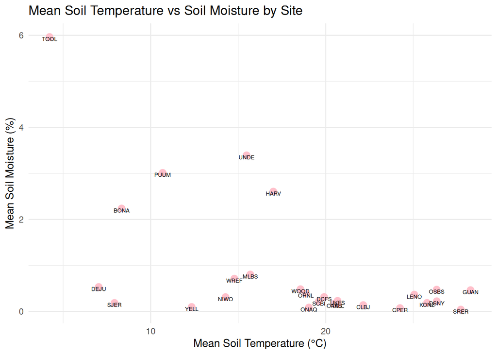

```r
site_means <- genome_groups_all_mean %>%
  group_by(siteID) %>%
  summarize(
    mean_soilTemp = mean(soilTemp, na.rm = TRUE),
    mean_soilMoisture = mean(soilMoisture, na.rm = TRUE)
  )

ggplot(site_means, aes(x = mean_soilTemp, y = mean_soilMoisture, label = siteID)) +
  geom_point(color = "pink", size = 3) +
  geom_text(vjust = 1, size = 2) +
  labs(
    title = "Mean Soil Temperature vs Soil Moisture by Site",
    x = "Mean Soil Temperature (°C)",
    y = "Mean Soil Moisture (%)"
  ) +
  theme_minimal()
```

### **Exercise 8**

Join your data frame from Ex 4 with the `NEON_MAGs_soil` data frame from lab 6.

```r
NEON_MAGs_soil <- read_tsv("/work/pi_bio678_umass_edu/data_NEON/exported_img_bins_Gs0166454_NEON.tsv")
```

```r
NEON_MAGs_prelim <- read_tsv("/work/pi_bio678_umass_edu/data_NEON/exported_img_bins_Gs0166454_NEON.tsv")
colnames(NEON_MAGs_soil)
```

```
 [1] "bin_oid"               "Bin ID"                "Genome Name"
 [4] "IMG Genome ID"         "Bin Quality"           "Bin Lineage"
 [7] "GTDB Taxonomy Lineage" "Bin Methods"           "Created By"
[10] "Date Added"            "Bin Completeness"      "Bin Contamination"
[13] "Average Coverage"      "Total Number of Bases" "5s rRNA"
[16] "16s rRNA"              "23s rRNA"              "tRNA Genes"
[19] "Gene Count"            "Scaffold Count"        "GOLD Study ID"
```

```r
colnames(NEON_MAGs_soil)
```

```
 [1] "bin_oid"               "Bin ID"                "Genome Name"
 [4] "IMG Genome ID"         "Bin Quality"           "Bin Lineage"
 [7] "GTDB Taxonomy Lineage" "Bin Methods"           "Created By"
[10] "Date Added"            "Bin Completeness"      "Bin Contamination"
[13] "Average Coverage"      "Total Number of Bases" "5s rRNA"
[16] "16s rRNA"              "23s rRNA"              "tRNA Genes"
[19] "Gene Count"            "Scaffold Count"        "GOLD Study ID"
```

```r
library(dplyr)
library(stringr)
library(readr)

NEON_MAGs_soil <- read_tsv("/work/pi_bio678_umass_edu/data_NEON/exported_img_bins_Gs0166454_NEON.tsv")

NEON_MAGs_soil <- NEON_MAGs_soil %>%
  mutate(Genome_Name_clean = str_replace_all(`Genome Name`, "-COMP", ""))

genome_MAGs_joined <- left_join(
  genome_groups_all_mean,
  NEON_MAGs_soil,
  by = c("genomicsSampleID" = "Genome_Name_clean")
)

head(genome_MAGs_joined)
```

```
# A tibble: 6 × 30
  genomicsSampleID       soilMoisture soilInWaterpH soilInCaClpH decimalLatitude
  <chr>                         <dbl>         <dbl>        <dbl>           <dbl>
1 BONA_001-O-20230710-C…         1.55          3.99         3.45            65.2
2 BONA_002-O-20230711-C…         1.14          4.35         3.82            65.2
3 BONA_004-O-20230712-C…         3.55          3.69         3.10            65.2
4 BONA_006-O-20230710-C…         2.54          4.05         3.48            65.2
5 BONA_009-O-20230711-C…         1.93          4.08         3.50            65.2
6 BONA_013-O-20230710-C…         2.45          3.97         3.42            65.2
# ℹ 25 more variables: decimalLongitude <dbl>, elevation <dbl>, soilTemp <dbl>,
#   siteID <chr>, bin_oid <chr>, `Bin ID` <chr>, `Genome Name` <chr>,
#   `IMG Genome ID` <dbl>, `Bin Quality` <chr>, `Bin Lineage` <chr>,
#   `GTDB Taxonomy Lineage` <chr>, `Bin Methods` <chr>, `Created By` <chr>,
#   `Date Added` <date>, `Bin Completeness` <dbl>, `Bin Contamination` <dbl>,
#   `Average Coverage` <lgl>, `Total Number of Bases` <dbl>, `5s rRNA` <dbl>,
#   `16s rRNA` <dbl>, `23s rRNA` <dbl>, `tRNA Genes` <dbl>, …
```

```r
summary(genome_MAGs_joined)
```

```
 genomicsSampleID    soilMoisture     soilInWaterpH    soilInCaClpH
 Length:293         Min.   : 0.0350   Min.   :3.351   Min.   :2.667
 Class :character   1st Qu.: 0.1437   1st Qu.:4.638   1st Qu.:3.901
 Mode  :character   Median : 0.2447   Median :5.372   Median :4.600
                    Mean   : 0.8759   Mean   :5.653   Mean   :5.010
                    3rd Qu.: 0.5143   3rd Qu.:6.645   3rd Qu.:5.975
                    Max.   :13.1933   Max.   :8.519   Max.   :7.953

 decimalLatitude decimalLongitude    elevation         soilTemp
 Min.   :17.96   Min.   :-155.34   Min.   :   9.8   Min.   : 3.10
 1st Qu.:33.33   1st Qu.:-112.46   1st Qu.: 289.9   1st Qu.:13.50
 Median :39.08   Median : -99.06   Median : 507.2   Median :18.67
 Mean   :40.80   Mean   :-103.91   Mean   : 739.4   Mean   :17.83
 3rd Qu.:46.23   3rd Qu.: -84.29   3rd Qu.: 931.5   3rd Qu.:23.60
 Max.   :68.67   Max.   : -66.82   Max.   :3540.9   Max.   :32.67
                                                    NA's   :1
    siteID            bin_oid             Bin ID          Genome Name
 Length:293         Length:293         Length:293         Length:293
 Class :character   Class :character   Class :character   Class :character
 Mode  :character   Mode  :character   Mode  :character   Mode  :character




 IMG Genome ID Bin Quality        Bin Lineage        GTDB Taxonomy Lineage
 Min.   : NA   Length:293         Length:293         Length:293
 1st Qu.: NA   Class :character   Class :character   Class :character
 Median : NA   Mode  :character   Mode  :character   Mode  :character
 Mean   :NaN
 3rd Qu.: NA
 Max.   : NA
 NA's   :293
 Bin Methods         Created By          Date Added  Bin Completeness
 Length:293         Length:293         Min.   :NA    Min.   : NA
 Class :character   Class :character   1st Qu.:NA    1st Qu.: NA
 Mode  :character   Mode  :character   Median :NA    Median : NA
                                       Mean   :NaN   Mean   :NaN
                                       3rd Qu.:NA    3rd Qu.: NA
                                       Max.   :NA    Max.   : NA
                                       NA's   :293   NA's   :293
 Bin Contamination Average Coverage Total Number of Bases    5s rRNA
 Min.   : NA       Mode:logical     Min.   : NA           Min.   : NA
 1st Qu.: NA       NA's:293         1st Qu.: NA           1st Qu.: NA
 Median : NA                        Median : NA           Median : NA
 Mean   :NaN                        Mean   :NaN           Mean   :NaN
 3rd Qu.: NA                        3rd Qu.: NA           3rd Qu.: NA
 Max.   : NA                        Max.   : NA           Max.   : NA
 NA's   :293                        NA's   :293           NA's   :293
    16s rRNA      23s rRNA     tRNA Genes    Gene Count  Scaffold Count
 Min.   : NA   Min.   : NA   Min.   : NA   Min.   : NA   Min.   : NA
 1st Qu.: NA   1st Qu.: NA   1st Qu.: NA   1st Qu.: NA   1st Qu.: NA
 Median : NA   Median : NA   Median : NA   Median : NA   Median : NA
 Mean   :NaN   Mean   :NaN   Mean   :NaN   Mean   :NaN   Mean   :NaN
 3rd Qu.: NA   3rd Qu.: NA   3rd Qu.: NA   3rd Qu.: NA   3rd Qu.: NA
 Max.   : NA   Max.   : NA   Max.   : NA   Max.   : NA   Max.   : NA
 NA's   :293   NA's   :293   NA's   :293   NA's   :293   NA's   :293
 GOLD Study ID
 Length:293
 Class :character
 Mode  :character
```

### **Exercise 9**

```r
soilpH_Example <- soilChem$sls_soilpH %>%
  dplyr::filter(sampleID %in% combinedTab$sampleID) %>%
  dplyr::select(sampleID,soilInWaterpH,soilInCaClpH)

combinedTab_pH <- left_join(combinedTab,soilpH_Example, by = "sampleID")

head(combinedTab_pH)
```

```
# A tibble: 6 × 5
  sampleID              genomicsSampleID soilMoisture soilInWaterpH soilInCaClpH
  <chr>                 <chr>                   <dbl>         <dbl>        <dbl>
1 HARV_034-O-23-202307… HARV_034-O-2023…         3.41          3.45         2.7
2 HARV_034-O-41-202307… HARV_034-O-2023…         2.98          3.28         2.6
3 HARV_034-O-39-202307… HARV_034-O-2023…         2.70          3.34         2.71
4 HARV_033-O-39-202307… HARV_033-O-2023…         3.48          3.85         3.04
5 HARV_033-O-21-202307… HARV_033-O-2023…         2.76          3.99         3.29
6 HARV_033-O-41-202307… HARV_033-O-2023…         3.31          3.63         2.84
```

```r
library(respirometry)

genome_groups_pH <- combinedTab_pH %>%
  group_by(genomicsSampleID) %>%
  summarize_at(c("soilInWaterpH","soilInCaClpH"), mean_pH)

head(genome_groups_pH)
```

```
# A tibble: 6 × 3
  genomicsSampleID         soilInWaterpH soilInCaClpH
  <chr>                            <dbl>        <dbl>
1 BONA_001-O-20230710-COMP          3.99         3.45
2 BONA_002-O-20230711-COMP          4.35         3.82
3 BONA_004-O-20230712-COMP          3.69         3.10
4 BONA_006-O-20230710-COMP          4.05         3.48
5 BONA_009-O-20230711-COMP          4.08         3.50
6 BONA_013-O-20230710-COMP          3.97         3.42
```

Make a table of the MAGs found in soils with a pH < 4.0.

```r
grep("pH", colnames(genome_MAGs_joined), value = TRUE)
```

```
[1] "soilInWaterpH" "soilInCaClpH"
```

```r
library(dplyr)

MAGs_low_pH <- genome_MAGs_joined %>%
  filter(soilInWaterpH < 4 | soilInCaClpH < 4) %>%
  select(genomicsSampleID, `Genome Name`, soilInWaterpH, soilInCaClpH)

MAGs_low_pH
```

```
# A tibble: 81 × 4
   genomicsSampleID         `Genome Name` soilInWaterpH soilInCaClpH
   <chr>                    <chr>                 <dbl>        <dbl>
 1 BONA_001-O-20230710-COMP <NA>                   3.99         3.45
 2 BONA_002-O-20230711-COMP <NA>                   4.35         3.82
 3 BONA_004-O-20230712-COMP <NA>                   3.69         3.10
 4 BONA_006-O-20230710-COMP <NA>                   4.05         3.48
 5 BONA_009-O-20230711-COMP <NA>                   4.08         3.50
 6 BONA_013-O-20230710-COMP <NA>                   3.97         3.42
 7 BONA_070-O-20230712-COMP <NA>                   4.28         3.77
 8 BONA_071-O-20230711-COMP <NA>                   4.20         3.66
 9 BONA_080-O-20230713-COMP <NA>                   3.95         3.32
10 DEJU_006-M-20230628-COMP <NA>                   4.34         3.85
# ℹ 71 more rows
```